# Lab Week 1

STAT5003

Dr. Justin Wishart

Semester 2, 2020

### Preparation and assumed knowledge

- Have a look at the **Lab** and make sure you have all packages installed on your computer.
- Download the `Cereal.csv` data file from Canvas for this lab.

### Aims

- In this intro lab, you will learn to write an `R` markdown file, run some simple code. The questions here aim to get you familiar with the `R` syntax.
- Please submit this tutorial on Canvas.

# 1 Data structure

Before you start the tutorial, *create a new RStudio project* in a new directory. Then, start your tutorial by writing your answers in a new *R Markdown file*.

# 2 File I/O

## 2.1 Read

1. Download the `Cereal.csv` file from the Canvas page and use the `read.csv` command to read in the csv file into `R` and assign it to the object called `cereal`.

**Solution**

```r
cereal <- read.csv("Cereal.csv", header = TRUE)
```

## 2.2 Data frames

1. There should be a default dataset in `R` called `cereal`. Use the `head` function to inspect the first few lines of the data frame and use `class` to check that `cereal` is in fact a data frame.

**Solution**

```r
data(cereal)
head(cereal)
```

```
##                        name mfr type calories protein fat sodium fiber carbo
## 1                 100%_Bran   N    C       70       4   1    130  10.0   5.0
## 2         100%_Natural_Bran   Q    C      120       3   5     15   2.0   8.0
## 3                  All-Bran   K    C       70       4   1    260   9.0   7.0
## 4 All-Bran_with_Extra_Fiber   K    C       50       4   0    140  14.0   8.0
## 5            Almond_Delight   R    C      110       2   2    200   1.0  14.0
## 6   Apple_Cinnamon_Cheerios   G    C      110       2   2    180   1.5  10.5
##   sugars potass vitamins shelf weight cups   rating
## 1      6    280       25     3      1 0.33 68.40297
## 2      8    135        0     3      1 1.00 33.98368
## 3      5    320       25     3      1 0.33 59.42551
## 4      0    330       25     3      1 0.50 93.70491
## 5      8     -1       25     3      1 0.75 34.38484
## 6     10     70       25     1      1 0.75 29.50954
```

```r
class(cereal)
```

```
## [1] "data.frame"
```

**Solution**

```r
colnames(cereal)
```

```
##  [1] "name"     "mfr"      "type"     "calories" "protein"  "fat"
##  [7] "sodium"   "fiber"    "carbo"    "sugars"   "potass"   "vitamins"
## [13] "shelf"    "weight"   "cups"     "rating"
```

```r
dim(cereal)
```

```
## [1] 77 16
```

```r
nrow(cereal)
```

```
## [1] 77
```

3. Extract the `calories` column using the `$` operator and using the `[[` operator.

**Solution**

```r
cereal$calories
```

```
##  [1]  70 120  70  50 110 110 110 130  90  90 120 110 120 110 110 110 100 110 110
## [20] 110 100 110 100 100 110 110 100 120 120 110 100 110 100 110 120 120 110 110
## [39] 110 140 110 100 110 100 150 150 160 100 120 140  90 130 120 100  50  50 100
## [58] 100 120 100  90 110 110  80  90  90 110 110  90 110 140 100 110 110 100 100
## [77] 110
```

```r
cereal[["calories"]]
```

```
##  [1]  70 120  70  50 110 110 110 130  90  90 120 110 120 110 110 110 100 110 110
## [20] 110 100 110 100 100 110 110 100 120 120 110 100 110 100 110 120 120 110 110
## [39] 110 140 110 100 110 100 150 150 160 100 120 140  90 130 120 100  50  50 100
## [58] 100 120 100  90 110 110  80  90  90 110 110  90 110 140 100 110 110 100 100
## [77] 110
```

4. Extract rows 1 to 10 from the `cereal` data frame.

**Solution**

```r
cereal[1:10,]
```

```
##                         name mfr type calories protein fat sodium fiber carbo
## 1                  100%_Bran   N    C       70       4   1    130  10.0   5.0
## 2          100%_Natural_Bran   Q    C      120       3   5     15   2.0   8.0
## 3                   All-Bran   K    C       70       4   1    260   9.0   7.0
## 4  All-Bran_with_Extra_Fiber   K    C       50       4   0    140  14.0   8.0
## 5             Almond_Delight   R    C      110       2   2    200   1.0  14.0
## 6    Apple_Cinnamon_Cheerios   G    C      110       2   2    180   1.5  10.5
## 7                Apple_Jacks   K    C      110       2   0    125   1.0  11.0
## 8                    Basic_4   G    C      130       3   2    210   2.0  18.0
## 9                  Bran_Chex   R    C       90       2   1    200   4.0  15.0
## 10               Bran_Flakes   P    C       90       3   0    210   5.0  13.0
##    sugars potass vitamins shelf weight cups   rating
## 1       6    280       25     3   1.00 0.33 68.40297
## 2       8    135        0     3   1.00 1.00 33.98368
## 3       5    320       25     3   1.00 0.33 59.42551
## 4       0    330       25     3   1.00 0.50 93.70491
## 5       8     -1       25     3   1.00 0.75 34.38484
## 6      10     70       25     1   1.00 0.75 29.50954
## 7      14     30       25     2   1.00 1.00 33.17409
## 8       8    100       25     3   1.33 0.75 37.03856
## 9       6    125       25     1   1.00 0.67 49.12025
## 10      5    190       25     3   1.00 0.67 53.31381
```

5. Make a new data frame called `Kelloggs` which only contains rows that belongs to manufacturer, Kellogs (when `mfr` takes the value `"K"`).

**Solution**

```r
Kelloggs <- subset(cereal, mfr == "K")
head(Kelloggs)
```

```
##                         name mfr type calories protein fat sodium fiber carbo
## 3                   All-Bran   K    C       70       4   1    260     9     7
## 4  All-Bran_with_Extra_Fiber   K    C       50       4   0    140    14     8
## 7                Apple_Jacks   K    C      110       2   0    125     1    11
## 17               Corn_Flakes   K    C      100       2   0    290     1    21
## 18                 Corn_Pops   K    C      110       1   0     90     1    13
## 20        Cracklin'_Oat_Bran   K    C      110       3   3    140     4    10
##    sugars potass vitamins shelf weight cups   rating
## 3       5    320       25     3      1 0.33 59.42551
## 4       0    330       25     3      1 0.50 93.70491
## 7      14     30       25     2      1 1.00 33.17409
## 17      2     35       25     1      1 1.00 45.86332
## 18     12     20       25     2      1 1.00 35.78279
## 20      7    160       25     3      1 0.50 40.44877
```

```r
## or
Kelloggs.2 <- cereal[cereal$mfr == "K", -2]
head(Kelloggs.2)
```

```
##                         name type calories protein fat sodium fiber carbo
## 3                   All-Bran    C       70       4   1    260     9     7
## 4  All-Bran_with_Extra_Fiber    C       50       4   0    140    14     8
## 7                Apple_Jacks    C      110       2   0    125     1    11
## 17               Corn_Flakes    C      100       2   0    290     1    21
## 18                 Corn_Pops    C      110       1   0     90     1    13
## 20        Cracklin'_Oat_Bran    C      110       3   3    140     4    10
##    sugars potass vitamins shelf weight cups   rating
## 3       5    320       25     3      1 0.33 59.42551
## 4       0    330       25     3      1 0.50 93.70491
## 7      14     30       25     2      1 1.00 33.17409
## 17      2     35       25     1      1 1.00 45.86332
## 18     12     20       25     2      1 1.00 35.78279
## 20      7    160       25     3      1 0.50 40.44877
```

```r
## or
cereal.splitted <- split(cereal, cereal$mfr)
Kelloggs.3 <- cereal.splitted[["K"]]
```

## 2.3 Factors

1. Load the `Cereal` data again with the `read.csv` command again. This time, use the optional argument, `stringsAsFactors = TRUE`.
2. The `mfr` and `type` columns are now factors. Check that this is true.

**Solution**

```r
cereal.with.factors <- read.csv("Cereal.csv", header = TRUE, stringsAsFactors = TRUE)
class(cereal.with.factors$mfr)
```

```
## [1] "factor"
```

```r
## or
class(cereal.with.factors$type)
```

```
## [1] "factor"
```

```r
## or
str(cereal.with.factors)
```

```
## 'data.frame':    77 obs. of  16 variables:
##  $ name    : Factor w/ 77 levels "100%_Bran","100%_Natural_Bran",..: 1 2 3 4 5 6 7 8 9 10 ...
##  $ mfr     : Factor w/ 7 levels "A","G","K","N",..: 4 6 3 3 7 2 3 2 7 5 ...
##  $ type    : Factor w/ 2 levels "C","H": 1 1 1 1 1 1 1 1 1 1 ...
##  $ calories: int  70 120 70 50 110 110 110 130 90 90 ...
##  $ protein : int  4 3 4 4 2 2 2 3 2 3 ...
##  $ fat     : int  1 5 1 0 2 2 0 2 1 0 ...
##  $ sodium  : int  130 15 260 140 200 180 125 210 200 210 ...
##  $ fiber   : num  10 2 9 14 1 1.5 1 2 4 5 ...
##  $ carbo   : num  5 8 7 8 14 10.5 11 18 15 13 ...
##  $ sugars  : int  6 8 5 0 8 10 14 8 6 5 ...
##  $ potass  : int  280 135 320 330 -1 70 30 100 125 190 ...
##  $ vitamins: int  25 0 25 25 25 25 25 25 25 25 ...
##  $ shelf   : int  3 3 3 3 3 1 2 3 1 3 ...
##  $ weight  : num  1 1 1 1 1 1 1 1.33 1 1 ...
##  $ cups    : num  0.33 1 0.33 0.5 0.75 0.75 1 0.75 0.67 0.67 ...
##  $ rating  : num  68.4 34 59.4 93.7 34.4 ...
```

2. How many levels are there in `mfr` and `type`? (use the functions `levels` or `nlevels`)

**Solution**

```r
levels(cereal.with.factors$mfr)
```

```
## [1] "A" "G" "K" "N" "P" "Q" "R"
```

```r
## or
nlevels(cereal.with.factors$mfr)
```

```
## [1] 7
```

```r
## or
str(cereal.with.factors$mfr)
```

```
##  Factor w/ 7 levels "A","G","K","N",..: 4 6 3 3 7 2 3 2 7 5 ...
```

## 2.4 Vectors

1. Extract the `calories` into a new vector called `cereal.calories`.

**Solution**

```r
cereal.calories <- cereal$calories
```

2. How many elements are there in `cereal.calories`? (`length`)

**Solution**

```r
length(cereal.calories)
```

```
## [1] 77
```

3. Extract the 5th to the 10th element from `cereal.calories`.

**Solution**

```r
cereal.calories[5:10]
```

```
## [1] 110 110 110 130  90  90
```

4. Add one more element to `cereal.calories` using `c()`.

**Solution**

```r
cereal.calories <- c(cereal.calories, 1.0)
length(cereal.calories)
```

```
## [1] 78
```

## 2.5 Matrix

1. Can you force the cereal data frame to be a Matrix? (`as.matrix(cereal)`). Check that the elements have been forced into the character type.

**Solution**

```r
cereal.matrix <- as.matrix(cereal)
str(cereal.matrix)
```

```
##  chr [1:77, 1:16] "100%_Bran" "100%_Natural_Bran" "All-Bran" ...
##  - attr(*, "dimnames")=List of 2
##   ..$ : NULL
##   ..$ : chr [1:16] "name" "mfr" "type" "calories" ...
```

2. Now do this again, but this time leave out the `mfr`, `name` and `type` columns. Check that the elements are now numeric.

**Solution**

```r
cereal.numeric.matrix <- as.matrix(cereal[,-(1:3)])
str(cereal.numeric.matrix)
```

```
##  num [1:77, 1:13] 70 120 70 50 110 110 110 130 90 90 ...
##  - attr(*, "dimnames")=List of 2
##   ..$ : NULL
##   ..$ : chr [1:13] "calories" "protein" "fat" "sodium" ...
```

# 3 Numerical summary

## 3.1 Summary

1. Use the `summary` function to extract the median, 1st quartile and 3rd quartile data from the `sodium` column.

**Solution**

```r
summary(cereal$sodium)
```

```
##    Min. 1st Qu.  Median    Mean 3rd Qu.    Max.
##     0.0   130.0   180.0   159.7   210.0   320.0
```

## 3.2 Basic statistics

2. Find the max, min, standard deviation and mean of the `sodium` (`max()`, `min()`, `sd()`, `mean()`)

**Solution**

```r
max(cereal$sodium)
```

```
## [1] 320
```

```r
min(cereal$sodium)
```

```
## [1] 0
```

```r
sd(cereal$sodium)
```

```
## [1] 83.8323
```

```r
mean(cereal$sodium)
```

```
## [1] 159.6753
```

3. Find the mean `sodium` of each `mfr`.

**Solution**

```r
# Can be done by repeated subsetting, this is tedious
kelloggs.cereals <- subset(cereal, mfr == "K")
mean(kelloggs.cereals$sodium)
```

```
## [1] 174.7826
```

```r
# Can use a formula and the aggregate function
aggregate(sodium ~ mfr, data = cereal, FUN = mean)
```

```
##   mfr   sodium
## 1   A   0.0000
## 2   G 200.4545
## 3   K 174.7826
## 4   N  37.5000
## 5   P 146.1111
## 6   Q  92.5000
## 7   R 198.1250
```

```r
# Can split vector (or data.frame if you wanted) by
# another vector. In this case, split by species.
split.sodium <- split(cereal$sodium, cereal$mfr)
# Apply a function over a list and return a list (_l_apply for list apply)
lapply(split.sodium, mean)
```

```
## $A
## [1] 0
##
## $G
## [1] 200.4545
##
## $K
## [1] 174.7826
##
## $N
## [1] 37.5
##
## $P
## [1] 146.1111
##
## $Q
## [1] 92.5
##
## $R
## [1] 198.125
```

```r
# Apply a function over a list and return a _s_implified format (_s_apply for simplify apply)
sapply(split.sodium, mean)
```

```
##        A        G        K        N        P        Q        R
##   0.0000 200.4545 174.7826  37.5000 146.1111  92.5000 198.1250
```

```r
# Also could use by and tapply, vapply, for the interested students, omitted here.
```

# 4 Graphical summary

## 4.1 Boxplot

1. Make a boxplot of the `sodium` against `mfr` using `boxplot()`.

**Solution**

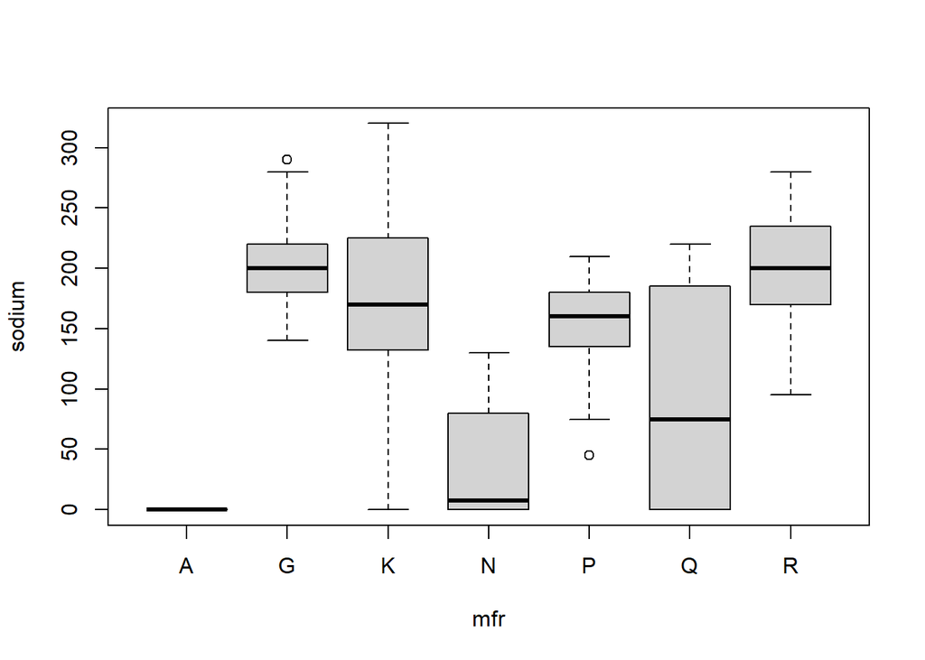

```r
boxplot(sodium ~ mfr, data = cereal)
```

## 4.2 plot?

2. Plot `calories` against `sodium` using `plot()`.

**Solution**

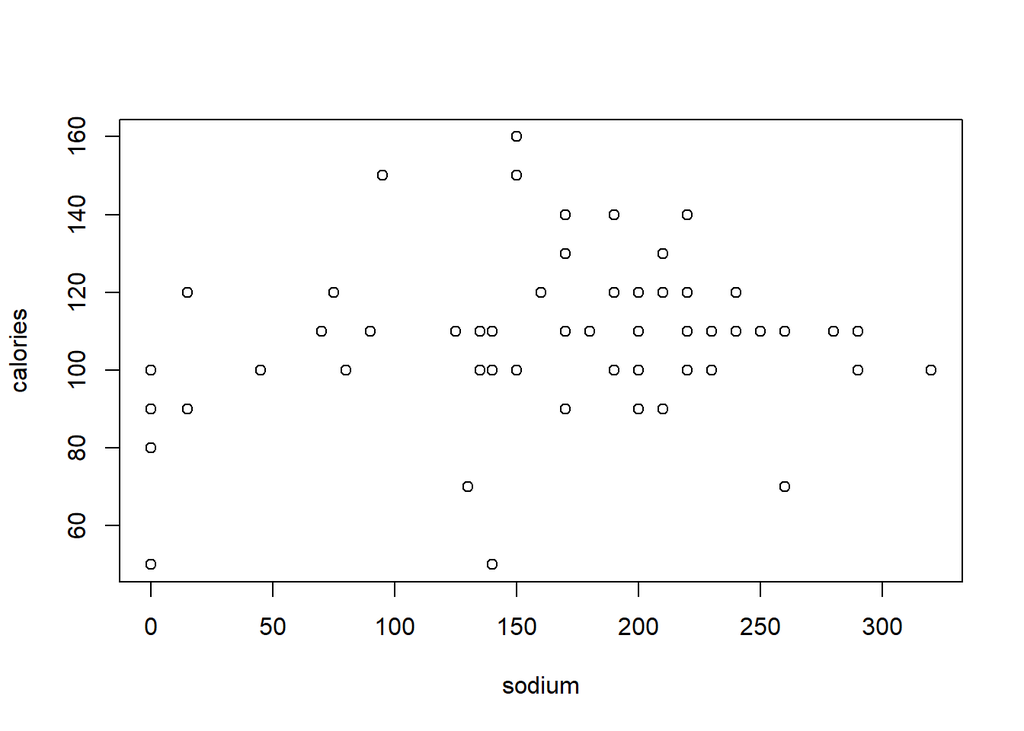

```r
# Using formula
plot(calories ~ sodium, data = cereal)
```

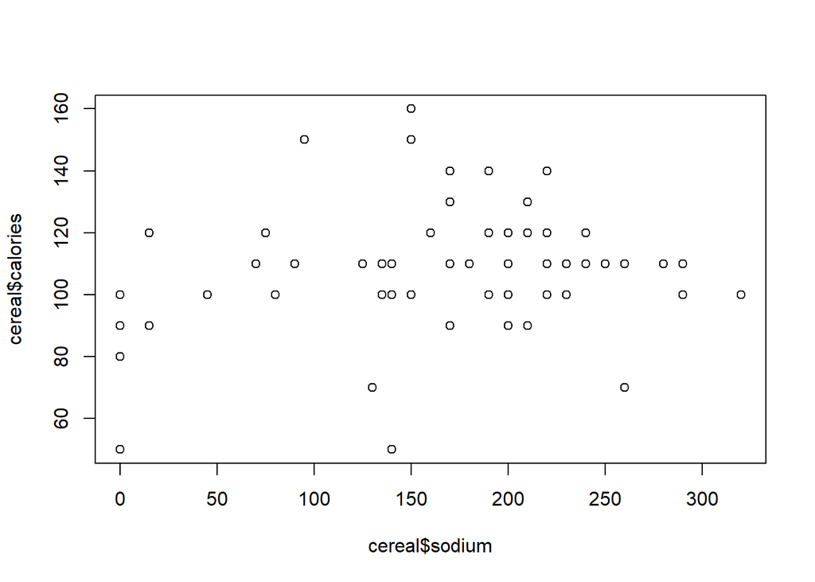

```r
# Another way, define x and y
plot(x = cereal$sodium, y = cereal$calories)
```

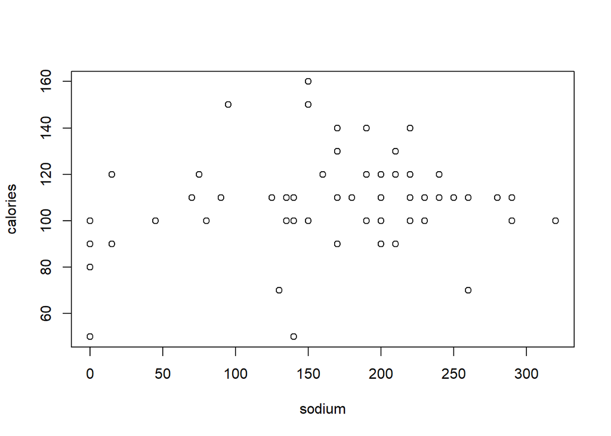

```r
# Alternatively, use with to help R find the vectors
with(cereal, plot(sodium, calories))
```

# 5 Write Data to File

**Solution**

```r
write.table(kelloggs.cereals, file = "kelloggs.csv")
```